# Smoothing of particle size data

Jacob Cram

23 November 2020

I have a data-set where particles of different sizes, at different depths in the ocean.

They are measured by an underwater vision profiler. This is a camera, that counts and sizes particles in a given volume of water.

There are frequently zero particles sampled and I’d like to use what I do know about relationships between particles across size and depth to estemate the abundances of particles of different sizes at different depth.

Here are a few things that I think are *mostly* true. 1) Particles follow power law size distribution spectrum. That is, when you normalize particle numbers to the width of the particle size bin (see below). They have a more or less linear relatinship such that log(number) ~ log(size).

2. Particles of any given size follow a power law size distribution with respect to depth, such that log(number) ~ log(depth).

I don’t expect these relationships to be perfect, so I’ve been using gams to allow for some deviation from these patterns.

I’d like to try using baysean approaches to see if I get similar results to these frequentist approaches.

```r
#data <- ESS %>% filter(depth <= 500, profile == "stn_043") %>% select(depth, lb, ub, vol, TotalParticles)
```

I am using tidyverse for data handling and mgcv for gams

```r
library(tidyverse)
library(mgcv)
```

```r
theme_set(theme_bw())
```

Here’s some data. This is one profile, truncated to the top 500m.

```r
data <- structure(list(depth = c(25, 25, 25, 25, 25, 25, 25, 25, 25,
25, 25, 25, 25, 25, 25, 25, 25, 25, 25, 25, 25, 25, 25, 25, 25,
75, 75, 75, 75, 75, 75, 75, 75, 75, 75, 75, 75, 75, 75, 75, 75,
75, 75, 75, 75, 75, 75, 75, 75, 75, 125, 125, 125, 125, 125,
125, 125, 125, 125, 125, 125, 125, 125, 125, 125, 125, 125, 125,
125, 125, 125, 125, 125, 125, 125, 175, 175, 175, 175, 175, 175,
175, 175, 175, 175, 175, 175, 175, 175, 175, 175, 175, 175, 175,
175, 175, 175, 175, 175, 175, 225, 225, 225, 225, 225, 225, 225,
225, 225, 225, 225, 225, 225, 225, 225, 225, 225, 225, 225, 225,
225, 225, 225, 225, 225, 275, 275, 275, 275, 275, 275, 275, 275,
275, 275, 275, 275, 275, 275, 275, 275, 275, 275, 275, 275, 275,
275, 275, 275, 275, 325, 325, 325, 325, 325, 325, 325, 325, 325,
325, 325, 325, 325, 325, 325, 325, 325, 325, 325, 325, 325, 325,
325, 325, 325, 375, 375, 375, 375, 375, 375, 375, 375, 375, 375,
375, 375, 375, 375, 375, 375, 375, 375, 375, 375, 375, 375, 375,
375, 375, 425, 425, 425, 425, 425, 425, 425, 425, 425, 425, 425,
425, 425, 425, 425, 425, 425, 425, 425, 425, 425, 425, 425, 425,
425, 475, 475, 475, 475, 475, 475, 475, 475, 475, 475, 475, 475,
475, 475, 475, 475, 475, 475, 475, 475, 475, 475, 475, 475, 475
), lb = c(0.102, 0.128, 0.161, 0.203, 0.256, 0.323, 0.406, 0.512,
0.645, 0.813, 1.02, 1.29, 1.63, 2.05, 2.58, 3.25, 4.1, 5.16,
6.5, 8.19, 10.3, 13, 16.4, 20.6, 26, 0.102, 0.128, 0.161, 0.203,
0.256, 0.323, 0.406, 0.512, 0.645, 0.813, 1.02, 1.29, 1.63, 2.05,
2.58, 3.25, 4.1, 5.16, 6.5, 8.19, 10.3, 13, 16.4, 20.6, 26, 0.102,
0.128, 0.161, 0.203, 0.256, 0.323, 0.406, 0.512, 0.645, 0.813,
1.02, 1.29, 1.63, 2.05, 2.58, 3.25, 4.1, 5.16, 6.5, 8.19, 10.3,
13, 16.4, 20.6, 26, 0.102, 0.128, 0.161, 0.203, 0.256, 0.323,
0.406, 0.512, 0.645, 0.813, 1.02, 1.29, 1.63, 2.05, 2.58, 3.25,
4.1, 5.16, 6.5, 8.19, 10.3, 13, 16.4, 20.6, 26, 0.102, 0.128,
0.161, 0.203, 0.256, 0.323, 0.406, 0.512, 0.645, 0.813, 1.02,
1.29, 1.63, 2.05, 2.58, 3.25, 4.1, 5.16, 6.5, 8.19, 10.3, 13,
16.4, 20.6, 26, 0.102, 0.128, 0.161, 0.203, 0.256, 0.323, 0.406,
0.512, 0.645, 0.813, 1.02, 1.29, 1.63, 2.05, 2.58, 3.25, 4.1,
5.16, 6.5, 8.19, 10.3, 13, 16.4, 20.6, 26, 0.102, 0.128, 0.161,
0.203, 0.256, 0.323, 0.406, 0.512, 0.645, 0.813, 1.02, 1.29,
1.63, 2.05, 2.58, 3.25, 4.1, 5.16, 6.5, 8.19, 10.3, 13, 16.4,
20.6, 26, 0.102, 0.128, 0.161, 0.203, 0.256, 0.323, 0.406, 0.512,
0.645, 0.813, 1.02, 1.29, 1.63, 2.05, 2.58, 3.25, 4.1, 5.16,
6.5, 8.19, 10.3, 13, 16.4, 20.6, 26, 0.102, 0.128, 0.161, 0.203,
0.256, 0.323, 0.406, 0.512, 0.645, 0.813, 1.02, 1.29, 1.63, 2.05,
2.58, 3.25, 4.1, 5.16, 6.5, 8.19, 10.3, 13, 16.4, 20.6, 26, 0.102,
0.128, 0.161, 0.203, 0.256, 0.323, 0.406, 0.512, 0.645, 0.813,
1.02, 1.29, 1.63, 2.05, 2.58, 3.25, 4.1, 5.16, 6.5, 8.19, 10.3,
13, 16.4, 20.6, 26), ub = c(0.128, 0.161, 0.203, 0.256, 0.323,
0.406, 0.512, 0.645, 0.813, 1.02, 1.29, 1.63, 2.05, 2.58, 3.25,
4.1, 5.16, 6.5, 8.19, 10.3, 13, 16.4, 20.6, 26, 32, 0.128, 0.161,
0.203, 0.256, 0.323, 0.406, 0.512, 0.645, 0.813, 1.02, 1.29,
1.63, 2.05, 2.58, 3.25, 4.1, 5.16, 6.5, 8.19, 10.3, 13, 16.4,
20.6, 26, 32, 0.128, 0.161, 0.203, 0.256, 0.323, 0.406, 0.512,
0.645, 0.813, 1.02, 1.29, 1.63, 2.05, 2.58, 3.25, 4.1, 5.16,
6.5, 8.19, 10.3, 13, 16.4, 20.6, 26, 32, 0.128, 0.161, 0.203,
0.256, 0.323, 0.406, 0.512, 0.645, 0.813, 1.02, 1.29, 1.63, 2.05,
2.58, 3.25, 4.1, 5.16, 6.5, 8.19, 10.3, 13, 16.4, 20.6, 26, 32,
0.128, 0.161, 0.203, 0.256, 0.323, 0.406, 0.512, 0.645, 0.813,
1.02, 1.29, 1.63, 2.05, 2.58, 3.25, 4.1, 5.16, 6.5, 8.19, 10.3,
13, 16.4, 20.6, 26, 32, 0.128, 0.161, 0.203, 0.256, 0.323, 0.406,
0.512, 0.645, 0.813, 1.02, 1.29, 1.63, 2.05, 2.58, 3.25, 4.1,
5.16, 6.5, 8.19, 10.3, 13, 16.4, 20.6, 26, 32, 0.128, 0.161,
0.203, 0.256, 0.323, 0.406, 0.512, 0.645, 0.813, 1.02, 1.29,
1.63, 2.05, 2.58, 3.25, 4.1, 5.16, 6.5, 8.19, 10.3, 13, 16.4,
20.6, 26, 32, 0.128, 0.161, 0.203, 0.256, 0.323, 0.406, 0.512,
0.645, 0.813, 1.02, 1.29, 1.63, 2.05, 2.58, 3.25, 4.1, 5.16,
6.5, 8.19, 10.3, 13, 16.4, 20.6, 26, 32, 0.128, 0.161, 0.203,
0.256, 0.323, 0.406, 0.512, 0.645, 0.813, 1.02, 1.29, 1.63, 2.05,
2.58, 3.25, 4.1, 5.16, 6.5, 8.19, 10.3, 13, 16.4, 20.6, 26, 32,
0.128, 0.161, 0.203, 0.256, 0.323, 0.406, 0.512, 0.645, 0.813,
1.02, 1.29, 1.63, 2.05, 2.58, 3.25, 4.1, 5.16, 6.5, 8.19, 10.3,
13, 16.4, 20.6, 26, 32), vol = c(1542.64, 1542.64, 1542.64, 1542.64,
1542.64, 1542.64, 1542.64, 1542.64, 1542.64, 1542.64, 1542.64,
1542.64, 1542.64, 1542.64, 1542.64, 1542.64, 1542.64, 1542.64,
1542.64, 1542.64, 1542.64, 1542.64, 1542.64, 1542.64, 1542.64,
563.2, 563.2, 563.2, 563.2, 563.2, 563.2, 563.2, 563.2, 563.2,
563.2, 563.2, 563.2, 563.2, 563.2, 563.2, 563.2, 563.2, 563.2,
563.2, 563.2, 563.2, 563.2, 563.2, 563.2, 563.2, 413.6, 413.6,
413.6, 413.6, 413.6, 413.6, 413.6, 413.6, 413.6, 413.6, 413.6,
413.6, 413.6, 413.6, 413.6, 413.6, 413.6, 413.6, 413.6, 413.6,
413.6, 413.6, 413.6, 413.6, 413.6, 402.16, 402.16, 402.16, 402.16,
402.16, 402.16, 402.16, 402.16, 402.16, 402.16, 402.16, 402.16,
402.16, 402.16, 402.16, 402.16, 402.16, 402.16, 402.16, 402.16,
402.16, 402.16, 402.16, 402.16, 402.16, 406.56, 406.56, 406.56,
406.56, 406.56, 406.56, 406.56, 406.56, 406.56, 406.56, 406.56,
406.56, 406.56, 406.56, 406.56, 406.56, 406.56, 406.56, 406.56,
406.56, 406.56, 406.56, 406.56, 406.56, 406.56, 397.76, 397.76,
397.76, 397.76, 397.76, 397.76, 397.76, 397.76, 397.76, 397.76,
397.76, 397.76, 397.76, 397.76, 397.76, 397.76, 397.76, 397.76,
397.76, 397.76, 397.76, 397.76, 397.76, 397.76, 397.76, 389.84,
389.84, 389.84, 389.84, 389.84, 389.84, 389.84, 389.84, 389.84,
389.84, 389.84, 389.84, 389.84, 389.84, 389.84, 389.84, 389.84,
389.84, 389.84, 389.84, 389.84, 389.84, 389.84, 389.84, 389.84,
410.96, 410.96, 410.96, 410.96, 410.96, 410.96, 410.96, 410.96,
410.96, 410.96, 410.96, 410.96, 410.96, 410.96, 410.96, 410.96,
410.96, 410.96, 410.96, 410.96, 410.96, 410.96, 410.96, 410.96,
410.96, 410.08, 410.08, 410.08, 410.08, 410.08, 410.08, 410.08,
410.08, 410.08, 410.08, 410.08, 410.08, 410.08, 410.08, 410.08,
410.08, 410.08, 410.08, 410.08, 410.08, 410.08, 410.08, 410.08,
410.08, 410.08, 410.08, 410.08, 410.08, 410.08, 410.08, 410.08,
410.08, 410.08, 410.08, 410.08, 410.08, 410.08, 410.08, 410.08,
410.08, 410.08, 410.08, 410.08, 410.08, 410.08, 410.08, 410.08,
410.08, 410.08, 410.08), TotalParticles = c(136084, 50891, 43620,
18820, 14902, 12063, 6635, 4518, 4229, 3081, 2606, 931, 222,
584, 782, 2, 0, 0, 624, 59, 633, 51, 0, 0, 0, 5204, 2056, 1971,
697, 557, 386, 229, 122, 63, 22, 12, 8, 3, 0, 1, 0, 0, 0, 0,
0, 0, 0, 0, 0, 0, 1596, 513, 571, 211, 131, 84, 36, 18, 12, 5,
3, 1, 0, 0, 0, 0, 0, 0, 0, 0, 0, 0, 0, 0, 0, 1950, 607, 594,
195, 120, 92, 32, 23, 10, 13, 1, 3, 1, 1, 0, 0, 0, 0, 0, 0, 0,
0, 0, 0, 0, 2083, 634, 642, 196, 116, 65, 21, 21, 8, 3, 0, 1,
0, 0, 0, 0, 0, 0, 0, 0, 0, 0, 0, 0, 0, 2231, 792, 721, 225, 117,
68, 25, 9, 15, 6, 3, 2, 0, 0, 0, 0, 0, 0, 0, 0, 0, 0, 0, 0, 0,
1796, 590, 695, 235, 137, 86, 31, 16, 11, 7, 3, 4, 1, 0, 0, 0,
0, 0, 0, 0, 0, 0, 0, 0, 0, 1928, 650, 711, 214, 135, 66, 19,
17, 5, 6, 2, 2, 0, 0, 0, 0, 0, 0, 0, 0, 0, 0, 0, 0, 0, 1901,
668, 712, 234, 150, 79, 20, 10, 4, 2, 2, 0, 0, 0, 0, 0, 0, 0,
0, 0, 0, 0, 0, 0, 0, 1808, 678, 785, 255, 157, 79, 31, 13, 2,
2, 0, 0, 0, 0, 0, 0, 0, 0, 0, 0, 0, 0, 0, 0, 0)), class = c("tbl_df",
"tbl", "data.frame"), row.names = c(NA, -250L))
```

Particles are binned by size. And the number of particles in each size bin, at each depth are recorded.

Here depth is measured as meters depth in the water column. `lb` is the lower bound of the size bin `ub` is the upper bound of the size bin, measured in mm, `vol` is the volume sampled (L) and `TotalParticles` are the number of particles seen in that bin.

```r
head(data)
```

| depth | lb | ub | vol | TotalParticles |
| --- | --- | --- | --- | --- |
| 25 | 0.102 | 0.128 | 1542.64 | 136084 |
| 25 | 0.128 | 0.161 | 1542.64 | 50891 |
| 25 | 0.161 | 0.203 | 1542.64 | 43620 |
| 25 | 0.203 | 0.256 | 1542.64 | 18820 |
| 25 | 0.256 | 0.323 | 1542.64 | 14902 |
| 25 | 0.323 | 0.406 | 1542.64 | 12063 |

I make a few extra parameters. `binsize` is the difference between `lb` and `ub`. `nparticles` are the particles normalized to volume, measured in (Particles/L) and `n_nparticles` is the number of particles normalized both to volume and bin-size (Particles/L/mm)

```r
data01 <- data %>% mutate(binsize = ub-lb, nparticles = TotalParticles/vol, n_nparticles = nparticles/binsize)
```

```r
data01 %>% head
```

| depth | lb | ub | vol | TotalParticles | binsize | nparticles | n_nparticles |
| --- | --- | --- | --- | --- | --- | --- | --- |
| 25 | 0.102 | 0.128 | 1542.64 | 136084 | 0.026 | 88.215008 | 3392.88492 |
| 25 | 0.128 | 0.161 | 1542.64 | 50891 | 0.033 | 32.989550 | 999.68334 |
| 25 | 0.161 | 0.203 | 1542.64 | 43620 | 0.042 | 28.276202 | 673.24290 |
| 25 | 0.203 | 0.256 | 1542.64 | 18820 | 0.053 | 12.199865 | 230.18614 |
| 25 | 0.256 | 0.323 | 1542.64 | 14902 | 0.067 | 9.660063 | 144.18005 |
| 25 | 0.323 | 0.406 | 1542.64 | 12063 | 0.083 | 7.819712 | 94.21339 |

First look at the data.

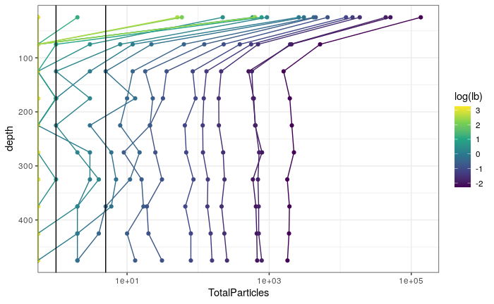

```r
data01Plot <- data01 %>% group_by(lb) %>% ggplot(aes(x = TotalParticles, y = depth, col = log(lb), group = lb)) + scale_y_reverse() + geom_point() + scale_x_log10() + scale_color_viridis_c() + geom_path() + geom_vline(xintercept = 1) + geom_vline(xintercept = 5)
data01Plot
```

Here you can see generally how these profiles look. There are lots of small particles, and fewer large particles. The largist particles are not detected below the shallowist depth. The intermediatly large particles (lb ≈ 1 mm) are sometimes detected a few times, sometimes once, and sometimes not at all, below the surface.

I can also show particle abundance, normalized to binsize and volume.

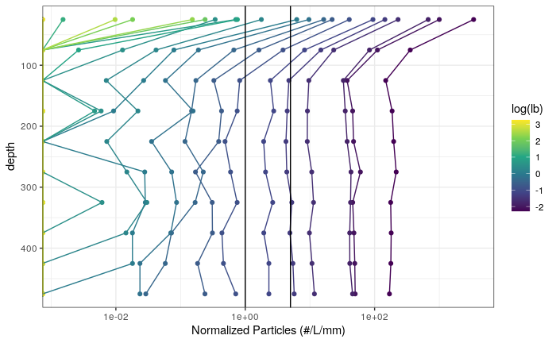

```r
nnPlot <- data01 %>% group_by(lb) %>% ggplot(aes(x = n_nparticles, y = depth, col = log(lb), group = lb)) + scale_y_reverse() + geom_point() + scale_x_log10() + scale_color_viridis_c() + geom_path() + geom_vline(xintercept = 1) + geom_vline(xintercept = 5) + labs(x = "Normalized Particles (#/L/mm)")
nnPlot
```

You can see that this looks similar to the plot above.

I would like to estemate the true abundance of all of these size fractions, but especially the particles of intermediate abundance, that show up sometimes once, sometimes a few times, and sometimes not at all.

I would like to estemate these from both the abundance of particles above and below that particle, but also from the abundance of smaller particles.

The data at each depth, sort-of follow a power law, where the log of the size is more-or-less linearly related to the log of the volume and bin-width normalized abundance.

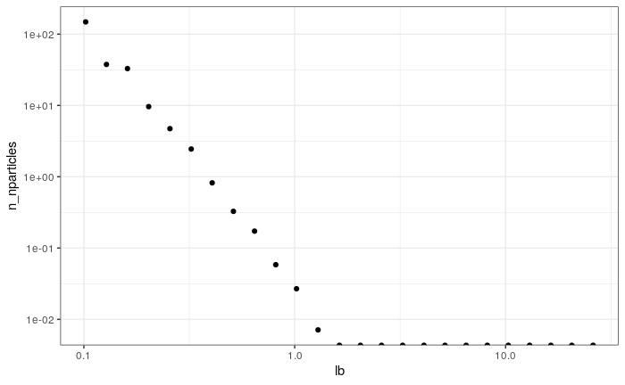

```r
data_125m <- data01 %>% filter(depth == 125)
data_125m %>% ggplot(aes(x = lb, y = n_nparticles)) + scale_x_log10() + scale_y_log10() + geom_point()
```

Of course, the large particles are so rare that we don’t detect them, so the line flattens off eventually.

I can fit this with a glm with a negative binomial family, if I assume that the particles are distributed at random.

```r
myGlm <- function(df){
  MASS::glm.nb(TotalParticles ~ log(lb) + offset(log(vol * binsize)), data = df)
}

mod_125m <- myGlm(data_125m)
summary(mod_125m)
```

```
Call:
MASS::glm.nb(formula = TotalParticles ~ log(lb) + offset(log(vol *
    binsize)), data = df, init.theta = 24.15904525, link = log)

Deviance Residuals:
     Min        1Q    Median        3Q       Max
-2.13560  -0.46147  -0.11136   0.00445   1.21859

Coefficients:
            Estimate Std. Error z value Pr(>|z|)
(Intercept)  -3.5576     0.1847  -19.27   <2e-16 ***
log(lb)      -3.7268     0.1163  -32.05   <2e-16 ***
---
Signif. codes:  0 ‘***’ 0.001 ‘**’ 0.01 ‘*’ 0.05 ‘.’ 0.1 ‘ ’ 1

(Dispersion parameter for Negative Binomial(24.159) family taken to be 1)

    Null deviance: 4943.903  on 24  degrees of freedom
Residual deviance:   11.462  on 23  degrees of freedom
AIC: 104.5

Number of Fisher Scoring iterations: 1

              Theta:  24.2
          Std. Err.:  12.4

 2 x log-likelihood:  -98.5
```

```r
pred_glm_125m <- predict(mod_125m, type = "link", se.fit = TRUE) %>% as_tibble %>% mutate(lower = fit - 2 * se.fit, upper = fit + 2 * se.fit) %>%
  mutate(glmFit = exp(fit), glmLower = exp(lower), glmUpper = exp(upper)) %>% select(-c(fit, lower, upper))
```

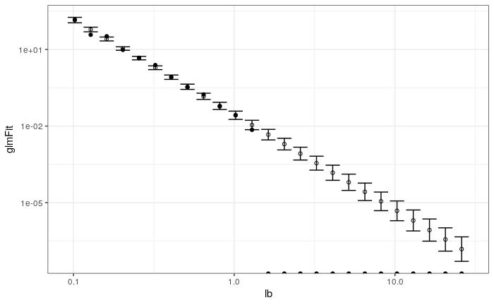

```r
df_125m <- bind_cols(data_125m, pred_glm_125m) %>% mutate(glmFit = glmFit/vol/binsize, glmLower = glmLower/vol/binsize, glmUpper = glmUpper/vol/binsize)

ggplot(df_125m, aes(x = lb)) + geom_point(aes(y = glmFit), shape = 1) + geom_point(aes(y = n_nparticles)) +
  geom_errorbar(aes(ymin = glmLower, ymax = glmUpper)) +
  scale_x_log10() + scale_y_log10()
```

So here, the open circles are the predicted values. For my subsequent analyses, I could for instance use these to estemate the larger particles, when we don’t see them, or all large particles.

Another option, is to use a gam. In this case, everything is pretty linear, but gams allow for some deviation from the power law relationship.

```r
myGam <- function(df){
  gam(TotalParticles ~ s(log(lb)), offset = log(vol * binsize), family = nb(), data = df)
}

mod1_125m <- myGam(data_125m)
summary(mod1_125m)
```

```
Family: Negative Binomial(20.049)
Link function: log

Formula:
TotalParticles ~ s(log(lb))

Parametric coefficients:
            Estimate Std. Error z value Pr(>|z|)
(Intercept)  -5.6740     0.4773  -11.89   <2e-16 ***
---
Signif. codes:  0 ‘***’ 0.001 ‘**’ 0.01 ‘*’ 0.05 ‘.’ 0.1 ‘ ’ 1

Approximate significance of smooth terms:
             edf Ref.df Chi.sq p-value
s(log(lb)) 1.527  1.895  978.5  <2e-16 ***
---
Signif. codes:  0 ‘***’ 0.001 ‘**’ 0.01 ‘*’ 0.05 ‘.’ 0.1 ‘ ’ 1

R-sq.(adj) =  0.953   Deviance explained = 99.8%
-REML = 51.475  Scale est. = 1         n = 25
```

```r
AIC(mod1_125m)
```

```
[1] 105.1696
```

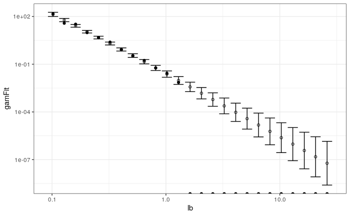

```r
pred1_tp_125m <- predict(mod1_125m, type = "link", se.fit = TRUE) %>% as.data.frame %>% mutate(lower = fit - 2 * se.fit, upper = fit + 2 * se.fit) %>%
  #translate back into response units
  mutate(gamFit = exp(fit), gamLower = exp(lower), gamUpper = exp(upper)) #%>% select(-c(fit, lower, upper))


df1_125m <- bind_cols(df_125m,  pred1_tp_125m)


ggplot(df1_125m, aes(x = lb)) + geom_point(aes(y = gamFit), shape = 1) +
  geom_errorbar(aes(ymin = gamLower, ymax = gamUpper)) +
  geom_point(aes(y = n_nparticles)) + scale_x_log10() + scale_y_log10()
```

Here are some bookkeeping functions, that allow us to redo the above calculations with one function.

```r
expand_with_gam <- function(df, mod){
  loc_pred <- predict(mod, type = "link", se.fit = TRUE) %>% as.data.frame %>% mutate(lower = fit - 2 * se.fit, upper = fit + 2 * se.fit) %>% mutate(resp_fit = exp(fit), resp_lower = exp(lower), resp_upper = exp(upper))
  loc_df <- bind_cols(df, loc_pred)
  loc_df
}

gam_size_ggplot <- function(df){
  ggplot(df, aes(x = lb)) + geom_point(aes(y = resp_fit), shape = 1) +
  geom_errorbar(aes(ymin = resp_lower, ymax = resp_upper)) +
  geom_point(aes(y = n_nparticles)) + scale_x_log10() + scale_y_log10()
}
```

Test

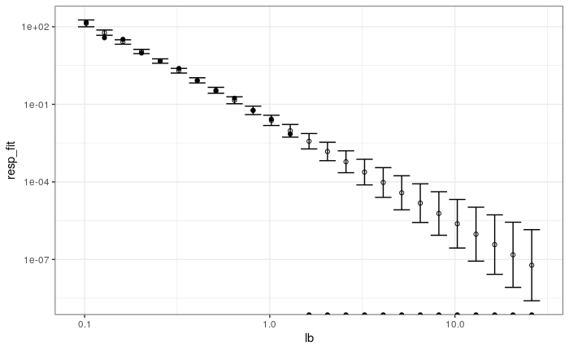

```r
expand_with_gam(df_125m, mod1_125m) %>% gam_size_ggplot
```

## Whole water column, by size only

I can loop the above gam over each depth, to estemate the size distribution throughout the water column.

```r
dataGamHorizontal <- data01 %>% group_by(depth) %>% nest %>% mutate(mod = map(data, myGam)) %>%
  mutate(data2 = map2(data, mod, expand_with_gam)) %>% select(-data, -mod)%>% unnest(data2)
dataGamHorizontal %>% head
```

| depth | lb | ub | vol | TotalParticles | binsize | nparticles | n_nparticles | fit | se.fit | lower | upper | resp_fit | resp_lower | resp_upper |
| --- | --- | --- | --- | --- | --- | --- | --- | --- | --- | --- | --- | --- | --- | --- |
| 25 | 0.102 | 0.128 | 1542.64 | 136084 | 0.026 | 88.215008 | 3392.88492 | 7.377322 | 0.6406195 | 6.096083 | 8.658561 | 1599.30162 | 444.11494 | 5759.2426 |
| 25 | 0.128 | 0.161 | 1542.64 | 50891 | 0.033 | 32.989550 | 999.68334 | 6.828498 | 0.6023803 | 5.623737 | 8.033259 | 923.80219 | 276.92240 | 3081.7676 |
| 25 | 0.161 | 0.203 | 1542.64 | 43620 | 0.042 | 28.276202 | 673.24290 | 6.274075 | 0.5648056 | 5.144463 | 7.403686 | 530.63515 | 171.47945 | 1642.0257 |
| 25 | 0.203 | 0.256 | 1542.64 | 18820 | 0.053 | 12.199865 | 230.18614 | 5.713786 | 0.5281346 | 4.657517 | 6.770055 | 303.01601 | 105.37406 | 871.3596 |
| 25 | 0.256 | 0.323 | 1542.64 | 14902 | 0.067 | 9.660063 | 144.18005 | 5.153089 | 0.4930318 | 4.167026 | 6.139153 | 172.96499 | 64.52325 | 463.6606 |
| 25 | 0.323 | 0.406 | 1542.64 | 12063 | 0.083 | 7.819712 | 94.21339 | 4.591180 | 0.4598148 | 3.671551 | 5.510810 | 98.61076 | 39.31282 | 247.3514 |

```
Transformation introduced infinite values in continuous x-axisTransformation introduced infinite values in continuous x-axisRemoved 7 rows containing missing values (geom_point).Removed 7 row(s) containing missing values (geom_path).
```

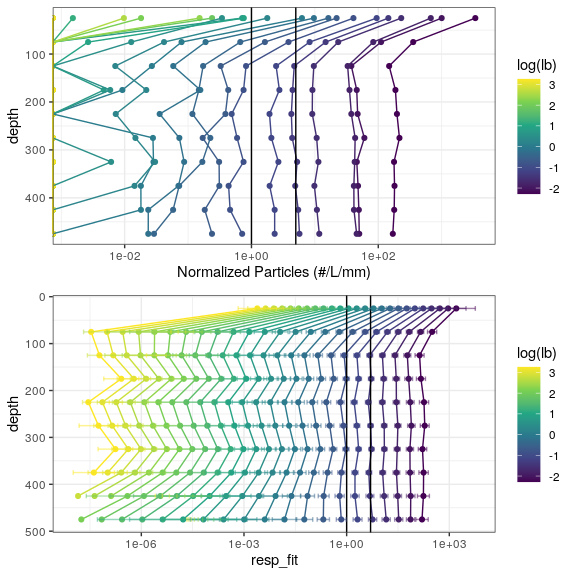

```r
library(cowplot)
horizontalGamPlot <- dataGamHorizontal %>% ggplot(aes(x = resp_fit, y = depth, col = log(lb), group = lb)) + scale_y_reverse() + geom_point() + scale_x_log10(limits = c(10^-8, NA)) + scale_color_viridis_c() + geom_path() + geom_vline(xintercept = 1) + geom_vline(xintercept = 5)  + geom_errorbar(aes(xmin = resp_lower, xmax = resp_upper), width = 10, alpha = 0.5)+ theme_bw()

plot_grid(nnPlot, horizontalGamPlot, nrow = 2)
```

Above you see the observed, and predicted values. The predicted values seem ok. However there is some jumping around between depths that could be real or not.

## Whole water column, by depth

Another option is to do just about the same thing, but this time look at the relationship between depths.

```r
verticalGam <- function(df){
  gam(TotalParticles ~ s(log(depth)), offset = log(vol * binsize), family = nb(), data = df)
}

dataGamVertical <- data01 %>% group_by(lb) %>% nest %>% mutate(mod = map(data, verticalGam)) %>%
  mutate(data2 = map2(data, mod, expand_with_gam)) %>% select(-data, -mod)%>% unnest(data2)
```

```
Fitting terminated with step failure - check results carefullyFitting terminated with step failure - check results carefullyFitting terminated with step failure - check results carefully
```

```r
dataGamVertical %>% head
```

| lb | depth | ub | vol | TotalParticles | binsize | nparticles | n_nparticles | fit | se.fit | lower | upper | resp_fit | resp_lower | resp_upper |
| --- | --- | --- | --- | --- | --- | --- | --- | --- | --- | --- | --- | --- | --- | --- |
| 0.102 | 25 | 0.128 | 1542.64 | 136084 | 0.026 | 88.215008 | 3392.8849 | 8.129695 | 0.05426551 | 8.021164 | 8.238226 | 3393.7651 | 3044.7200 | 3782.8246 |
| 0.102 | 75 | 0.128 | 563.20 | 5204 | 0.026 | 9.240057 | 355.3868 | 5.860172 | 0.05525510 | 5.749662 | 5.970682 | 350.7846 | 314.0845 | 391.7729 |
| 0.102 | 125 | 0.128 | 413.60 | 1596 | 0.026 | 3.858801 | 148.4154 | 5.042350 | 0.05565390 | 4.931042 | 5.153658 | 154.8334 | 138.5238 | 173.0633 |
| 0.102 | 175 | 0.128 | 402.16 | 1950 | 0.026 | 4.848816 | 186.4929 | 5.197531 | 0.05106997 | 5.095391 | 5.299671 | 180.8252 | 163.2677 | 200.2709 |
| 0.102 | 225 | 0.128 | 406.56 | 2083 | 0.026 | 5.123475 | 197.0567 | 5.306283 | 0.04698902 | 5.212305 | 5.400261 | 201.5994 | 183.5165 | 221.4641 |
| 0.102 | 275 | 0.128 | 397.76 | 2231 | 0.026 | 5.608910 | 215.7273 | 5.317017 | 0.04393645 | 5.229144 | 5.404890 | 203.7751 | 186.6330 | 222.4918 |

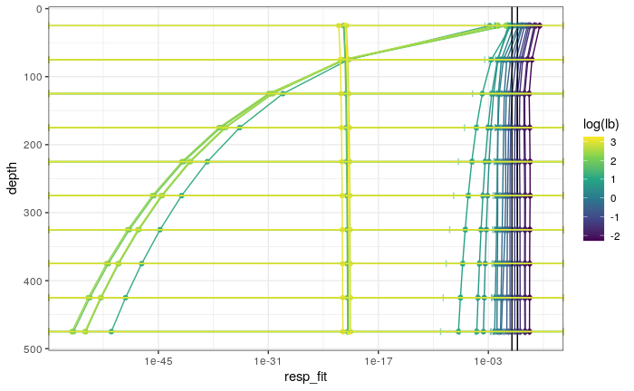

```r
verticalGamPlot <- dataGamVertical %>% ggplot(aes(x = resp_fit, y = depth, col = log(lb), group = lb)) + scale_y_reverse() + geom_point() + scale_x_log10() + scale_color_viridis_c() + geom_path() + geom_vline(xintercept = 1) + geom_vline(xintercept = 5) + geom_errorbar(aes(xmin = resp_lower, xmax = resp_upper), width = 10, alpha = 0.5) + theme_bw()
verticalGamPlot
```

That said, for the smaller size particles, these seem reasonable.

# Depth and Size Together

I can also use a gam to try to use size and depth together:

```r
doubleSmooth <- gam(TotalParticles ~s(log(lb), log(depth)), offset = log(vol * binsize), family = nb(), data = data01)

#doubleSmooth <- gam(TotalParticles ~ s(log(lb)) + log(depth), offset = log(vol * binsize), family = quasipoisson(), data = data01)
```

```r
summary(doubleSmooth)
```

```
Family: Negative Binomial(2.511)
Link function: log

Formula:
TotalParticles ~ s(log(lb), log(depth))

Parametric coefficients:
            Estimate Std. Error z value Pr(>|z|)
(Intercept)  -6.1513     0.6745   -9.12   <2e-16 ***
---
Signif. codes:  0 ‘***’ 0.001 ‘**’ 0.01 ‘*’ 0.05 ‘.’ 0.1 ‘ ’ 1

Approximate significance of smooth terms:
                        edf Ref.df Chi.sq p-value
s(log(lb),log(depth)) 17.73  20.37   3224  <2e-16 ***
---
Signif. codes:  0 ‘***’ 0.001 ‘**’ 0.01 ‘*’ 0.05 ‘.’ 0.1 ‘ ’ 1

R-sq.(adj) =  0.982   Deviance explained = 98.2%
-REML = 766.93  Scale est. = 1         n = 250
```

```r
AIC(doubleSmooth)
```

```
[1] 1505.119
```

Just confirming that the smooth term with both components does a beter job than a linear relationship including both variables.

```r
linearSum <- gam(TotalParticles ~ log(lb) + log(depth), offset = log(vol * binsize), family = nb(), data = data01)
summary(linearSum)
```

```
Family: Negative Binomial(0.492)
Link function: log

Formula:
TotalParticles ~ log(lb) + log(depth)

Parametric coefficients:
            Estimate Std. Error z value Pr(>|z|)
(Intercept)  9.92394    0.62560   15.86   <2e-16 ***
log(lb)     -3.36701    0.08778  -38.36   <2e-16 ***
log(depth)  -2.28903    0.12350  -18.53   <2e-16 ***
---
Signif. codes:  0 ‘***’ 0.001 ‘**’ 0.01 ‘*’ 0.05 ‘.’ 0.1 ‘ ’ 1


R-sq.(adj) =  -64.2   Deviance explained = 89.3%
-REML = 871.01  Scale est. = 1         n = 250
```

```r
multSum <- gam(TotalParticles ~ log(lb) * log(depth), offset = log(vol * binsize), family = nb(), data = data01)
summary(multSum)
```

```
Family: Negative Binomial(1.179)
Link function: log

Formula:
TotalParticles ~ log(lb) * log(depth)

Parametric coefficients:
                   Estimate Std. Error z value Pr(>|z|)
(Intercept)         8.68044    0.45473  19.089   <2e-16 ***
log(lb)             0.18339    0.28292   0.648    0.517
log(depth)         -2.26278    0.09852 -22.967   <2e-16 ***
log(lb):log(depth) -0.78051    0.06372 -12.248   <2e-16 ***
---
Signif. codes:  0 ‘***’ 0.001 ‘**’ 0.01 ‘*’ 0.05 ‘.’ 0.1 ‘ ’ 1


R-sq.(adj) =  0.484   Deviance explained = 95.6%
-REML = 802.15  Scale est. = 1         n = 250
```

```r
AIC(linearSum,
  multSum,
  doubleSmooth
)
```

|  | df | AIC |
| --- | --- | --- |
| linearSum | 4.00000 | 1741.827 |
| multSum | 5.00000 | 1600.155 |
| doubleSmooth | 20.37886 | 1505.119 |

Here I predict the variables:

```r
predDS <- predict(doubleSmooth, type = "link", se.fit = TRUE)

dataPredDS <- data01 %>% bind_cols(link_pred = predDS$fit, link_se = predDS$se) %>%
  mutate(link_lower = link_pred - 2 * link_se, link_upper = link_pred + 2 * link_se) %>%
  mutate(resp_pred = exp(link_pred), resp_lower = exp(link_lower), resp_upper = exp(link_upper))
```

Original data, again, for reference.

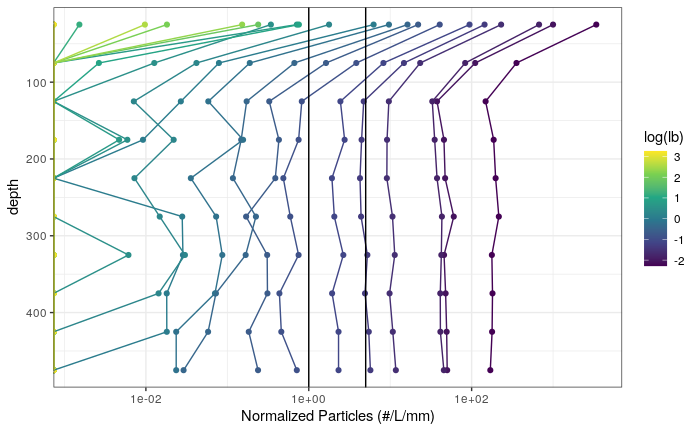

```r
nnPlot
```

Gam data.

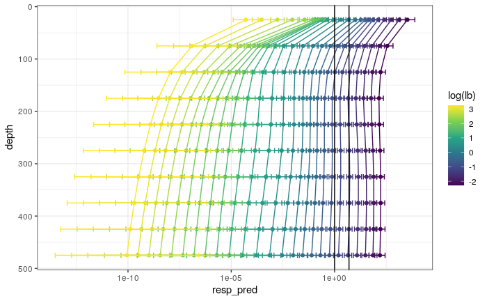

```r
predDSPlot <- dataPredDS %>% group_by(lb) %>% ggplot(aes(x = resp_pred, y = depth, col = log(lb), group = lb)) + scale_y_reverse() + geom_point() + geom_errorbar(aes(xmin = resp_lower, xmax = resp_upper), width = 10) +  scale_color_viridis_c() + geom_path() + geom_vline(xintercept = 1) + geom_vline(xintercept = 5)  + scale_x_log10()
predDSPlot
```

As above, but focusing on the at least sort-of abundant particles.

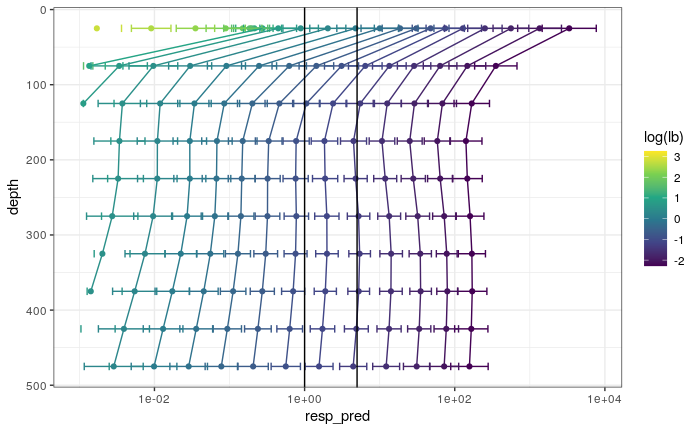

```r
#predDSPlot + scale_x_log10(limits = c(1e-22, NA))
predDSPlot + scale_x_log10(limits = c(1e-3, NA))
```

So in general, I like this two component gam model. That said, I’d be interested to see if we can pull additonal insight from higherarchical baysean approaches.

-Jacob